# Principal Elements of Mixed-Sign Coxeter Systems

Executable Python Computations, Signed-Graph Visualizations, and Lean 4 Formalizations

Author

Affiliation

J Kyle Armstrong, PhD

Lewis Katz School of Medicine at Temple University Center for Biostatistics & Epidemiology

Published

Nov 28, 2026

Abstract

We present a Lean 4 formalization and companion Python package (`mixed_sign_coxeter`) for the core theorems and counterexamples of Armstrong’s 2012 dissertation on *Principal Elements of Mixed-Sign Coxeter Systems*. Mixed-sign Coxeter systems generalize classical Coxeter groups by allowing both positive and negative diagonal entries in the defining symmetric bilinear form, represented visually by signed Coxeter graphs. Using Lean 4 (`v4.35.0`) and Mathlib, we formally verify Howlett’s upper-triangular matrix factorization for principal elements, establish graph-reduction conjugacy theorems (bipartite sign-negation, component splitting, and tree leaf-insertion), and construct machine-checked counterexamples showing that odd negative cycles violate the classical Deletion Property and break spectral-radius monotonicity. All source code and artifacts are available at https://github.com/jkylearmstrong/mixed.sign.coxeter.systems.

## 1 Overview

This document is an executable mathematical writeup accompanying Johnathon Kyle Armstrong’s dissertation, *Principal Elements of Mixed-Sign Coxeter Systems* (Armstrong 2012) ([FSU Digital Library PDF](https://repository.lib.fsu.edu/islandora/object/fsu:182755/datastream/PDF/view) · [Download](https://repository.lib.fsu.edu/islandora/object/fsu:182755/datastream/PDF/download)). Classical Coxeter theory is treated in Humphreys (1990), and the upper-triangular matrix factorization of Coxeter elements is due to Howlett (1982). The formalization is built in Lean 4 (Moura and Ullrich 2021) atop Mathlib (The mathlib Community 2020), with full source code hosted at https://github.com/jkylearmstrong/mixed.sign.coxeter.systems. It brings together three layers:

1. **Python (`mixed_sign_coxeter`)**: Exact symbolic computations of bilinear forms $B(\Gamma)$, signatures, Howlett’s upper-triangular matrix $U$, principal polynomials $\chi_w(x)$, spectral radii $\rho(w)$, and finite/infinite group enumeration.
2. **Visualizations (`matplotlib`)**: Signed Coxeter diagrams ($+$ vs. $-$ nodes) and complex-plane eigenvalue spectra relative to the unit circle.
3. **Lean 4 Formalizations (`MixedSignCoxeter`)**: Machine-checked, `sorry`-free proofs of the core structural theorems and counterexamples across Chapters 1–3, built against Mathlib (`v4.35.0`).

## 2 Reflection Systems, Conjugacy, Trees, and Howlett’s Theorem

**Theorem 1 (Reflection Systems and Howlett’s Formula)** *Results covered: Theorem 1.1 & Lemma 2.63.*

A **reflection system** $(W, S, B)$ on $\mathbb{R}^n$ is determined by a symmetric $n \times n$ bilinear form $B$ with nonzero diagonal entries $B_{ii} \neq 0$. Each basis vector $e_i$ defines a generating reflection
$$s_i(v) = v - \frac{2 B(e_i, v)}{B(e_i, e_i)} e_i,$$
which satisfies $s_i^2 = I$ ([`reflectionMatrix_mul_self`](https://github.com/jkylearmstrong/mixed.sign.coxeter.systems/blob/main/lean/MixedSignCoxeter/ReflectionSystem.lean#L66)) and preserves $B$ ([`reflectionMatrix_preserves_B`](https://github.com/jkylearmstrong/mixed.sign.coxeter.systems/blob/main/lean/MixedSignCoxeter/ReflectionSystem.lean#L88), Proposition 2.17).

To compute the **principal element** $w = s_0 s_1 \cdots s_{n-1}$ and its characteristic polynomial without multiplying $n$ reflection matrices directly, Howlett’s theorem introduces the upper-triangular matrix $U$. In the dissertation, $U$ has diagonal entries $U_{ii} = \frac{1}{2} B_{ii}$ and upper-triangular entries $U_{ij} = B_{ij}$ ($i < j$). In [`Howlett.lean`](https://github.com/jkylearmstrong/mixed.sign.coxeter.systems/blob/main/lean/MixedSignCoxeter/Howlett.lean), we define `howlettU S.B` with $2\times$ scaling ($U_{ii} = B_{ii}$ and $U_{ij} = 2 B_{ij}$ for $i < j$); because scaling $U$ by $2$ leaves $U w = -U^T$ and $w = -U^{-1} U^T$ unchanged, the two definitions are mathematically equivalent. Since $\det U = \prod_{i=0}^{n-1} U_{ii} \neq 0$, $U$ is invertible, and:
$$U w = -U^T \quad \Longleftrightarrow \quad w = -U^{-1} U^T,$$
which immediately gives Lemma 2.63: $\chi_w(x) = \det(x I - w) = (\det U)^{-1} \det(x U + U^T)$.

#### Lean 4 Proof

Rather than inverting $U$ case by case ([`Howlett.lean`](https://github.com/jkylearmstrong/mixed.sign.coxeter.systems/blob/main/lean/MixedSignCoxeter/Howlett.lean)), [`howlett_U_mul_principalElement`](https://github.com/jkylearmstrong/mixed.sign.coxeter.systems/blob/main/lean/MixedSignCoxeter/Howlett.lean#L174) proves $U(s_0 \cdots s_{n-1}) = -U^T$ for *arbitrary* dimension $n$ by induction on the prefix product `prefixProd S k = s_0 ⋯ s_{k-1}`: multiplying by $s_k$ flips row $k$ of $U$ from its upper-triangular entries to its lower-triangular transpose entries while leaving rows $< k$ fixed. Invertibility of `howlettU S.B` ([`howlettU_det_ne_zero`](https://github.com/jkylearmstrong/mixed.sign.coxeter.systems/blob/main/lean/MixedSignCoxeter/Howlett.lean#L192), proved via `Matrix.det_of_isUpperTriangular`) then yields [`howlett_principalElement_eq_neg_inv_mul_transpose`](https://github.com/jkylearmstrong/mixed.sign.coxeter.systems/blob/main/lean/MixedSignCoxeter/Howlett.lean#L219) and [`principal_charpoly_eq`](https://github.com/jkylearmstrong/mixed.sign.coxeter.systems/blob/main/lean/MixedSignCoxeter/Howlett.lean#L199):

```
theorem howlett_U_mul_principalElement (S : ReflectionSystem n) :
    howlettU S.B * principalElement S = -(howlettU S.B)ᵀ

theorem howlett_principalElement_eq_neg_inv_mul_transpose (S : ReflectionSystem n) :
    principalElement S = -(howlettU S.B)⁻¹ * (howlettU S.B)ᵀ

theorem principal_charpoly_eq (S : ReflectionSystem n) (x : ℝ) :
    (x • (1 : Matrix (Fin n) (Fin n) ℝ) - principalElement S).det =
      (howlettU S.B).det⁻¹ * (x • howlettU S.B + (howlettU S.B)ᵀ).det
```

#### Python Verification

To illustrate Theorem 1.1 and Lemma 2.63 on a non-trivial mixed-sign system where the reflections do not commute and irrational edge weights appear, consider the 4-node linear graph $\Gamma$ with node signs $(+, -, +, +)$ and edge weights $m(0,1)=3$, $m(1,2)=4$, $m(2,3)=6$. Howlett’s formula yields the principal polynomial
$$\chi_w(x) = x^4 + 4x^3 + 3x^2 + 4x + 1,$$
which we verify below alongside the direct matrix product $s_0 s_1 s_2 s_3 = -U^{-1} U^T$:

```
B(Gamma) =
⎡2   -1    0    0 ⎤
⎢                 ⎥
⎢-1  -2   -√2   0 ⎥
⎢                 ⎥
⎢0   -√2   2   -√3⎥
⎢                 ⎥
⎣0    0   -√3   2 ⎦

Theorem 1.1 check (s0*s1*s2*s3 - (-U^{-1} U^T) == 0): True
Principal polynomial: x**4 + 4*x**3 + 3*x**2 + 4*x + 1
```

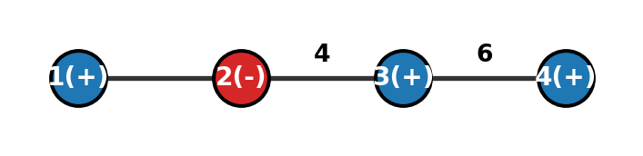

```python
g_howlett = MixedSignCoxeterGraph(["+", "-", "+", "+"], [(0, 1, 3), (1, 2, 4), (2, 3, 6)])


draw_signed_graph(g_howlett)

w_direct = evaluate_word(g_howlett, list(range(g_howlett.n)))
w_howlett = g_howlett.principal_element()
x = sp.Symbol("x")
chi_howlett = g_howlett.principal_polynomial(var=x)

print("B(Gamma) =")
sp.pprint(g_howlett.B)
print("\nTheorem 1.1 check (s0*s1*s2*s3 - (-U^{-1} U^T) == 0):",
      sp.simplify(w_direct - w_howlett) == sp.zeros(4, 4))
print("Principal polynomial:", sp.factor(chi_howlett.as_expr()))
```

### 2.1 Bipartite Conjugation

*Results covered: Theorem 1.4 & Corollary 1.5.*

If a reflection graph $\Gamma$ is **bipartite** with bipartition $N_1 \sqcup N_2$, let $P \in \mathcal{O}$ be the diagonal signed-permutation matrix ([`bipartiteConjugator`](https://github.com/jkylearmstrong/mixed.sign.coxeter.systems/blob/main/lean/MixedSignCoxeter/Bipartite.lean#L42)) that equals $+1$ on $N_1$ and $-1$ on $N_2$. Conjugating $B(\Gamma)$ by $P$ leaves all diagonal entries unchanged and negates every off-diagonal entry (since every edge connects $N_1$ to $N_2$). Equivalently, $P^T B(\Gamma) P = -B(\Gamma_-)$, where $\Gamma_-$ is obtained by flipping every node sign.

Because negating a bilinear form leaves every reflection $s_i$ unchanged ([`reflectionMatrix_neg`](https://github.com/jkylearmstrong/mixed.sign.coxeter.systems/blob/main/lean/MixedSignCoxeter/ReflectionSystem.lean#L60), Lemma 2.31), conjugation by $P$ sends every generator $s_i(\Gamma)$, every word product $w(\Gamma)$, and the characteristic polynomial $\chi_w(x)$ to those of $\Gamma_-$.

#### Lean 4 Proof

In [`Bipartite.lean`](https://github.com/jkylearmstrong/mixed.sign.coxeter.systems/blob/main/lean/MixedSignCoxeter/Bipartite.lean) and [`MixedSign.lean`](https://github.com/jkylearmstrong/mixed.sign.coxeter.systems/blob/main/lean/MixedSignCoxeter/MixedSign.lean), `BipartiteReflectionSystem n` packages a `ReflectionSystem n` together with a partition `part : Fin n → Bool` and a proof that `B i j = 0` whenever `part i = part j` and `i ≠ j`. Entrywise computation proves [`bipartite_conjugation_theorem`](https://github.com/jkylearmstrong/mixed.sign.coxeter.systems/blob/main/lean/MixedSignCoxeter/Bipartite.lean#L65), which immediately lifts via [`conjugate_reflections_of_neg_form`](https://github.com/jkylearmstrong/mixed.sign.coxeter.systems/blob/main/lean/MixedSignCoxeter/Conjugacy.lean#L127) (Lemma 2.32) to reflections, arbitrary word products, and characteristic polynomials; [`bipartite_mixed_sign_conjugation`](https://github.com/jkylearmstrong/mixed.sign.coxeter.systems/blob/main/lean/MixedSignCoxeter/MixedSign.lean#L122) specializes this to [`MixedSignCoxeterGraph`](https://github.com/jkylearmstrong/mixed.sign.coxeter.systems/blob/main/lean/MixedSignCoxeter/MixedSign.lean#L64) (Corollary 1.5):

```
theorem bipartite_conjugation_theorem (G : BipartiteReflectionSystem n) :
    (bipartiteConjugator G.part)ᵀ * G.B * bipartiteConjugator G.part =
      -negateDiag G.B

theorem bipartite_conjugates_charpoly (G : BipartiteReflectionSystem n) (w : List (Fin n)) (x : ℝ) :
    (x • (1 : Matrix (Fin n) (Fin n) ℝ) - wordProd G.toReflectionSystem w).det =
      (x • (1 : Matrix (Fin n) (Fin n) ℝ) -
        (w.map (reflectionMatrix (negateDiag G.B))).prod).det

theorem bipartite_mixed_sign_conjugation (Γ : MixedSignCoxeterGraph n)
    (part : Fin n → Bool)
    (hbp : ∀ i j : Fin n, part i = part j → i ≠ j → Γ.toBilinearForm i j = 0) :
    (ReflectionSystem.bipartiteConjugator part)ᵀ * Γ.toBilinearForm *
        ReflectionSystem.bipartiteConjugator part =
      -Γ.negateSigns.toBilinearForm
```

#### Python Verification

On the 4-node path graph $A_4(+, -, +, +)$ (which is bipartite with $N_1 = \{0, 2\}$ and $N_2 = \{1, 3\}$), we verify that $P^T B(\Gamma) P = -B(\Gamma_-)$ and that $A_4(+, -, +, +)$ and $A_4(-, +, -, -)$ share the exact same principal polynomial:

```python
g_bp = MixedSignCoxeterGraph.A_n(["+", "-", "+", "+"])
g_bp_neg = g_bp.negate_signs()
P = g_bp.bipartite_conjugator()

print("P^T B(Gamma) P + B(Gamma_-) == 0:",
      sp.simplify(P.T * g_bp.B * P + g_bp_neg.B) == sp.zeros(g_bp.n, g_bp.n))
print("Equal principal polynomials:",
      g_bp.principal_polynomial(var=x) == g_bp_neg.principal_polynomial(var=x))
```

```
P^T B(Gamma) P + B(Gamma_-) == 0: True
Equal principal polynomials: True
```

### 2.2 Graph Isomorphism, Signatures, Components, and Trees

Chapter 2 establishes the structural invariants of reflection systems under signed-permutation conjugacy ($\mathcal{O}$-conjugacy, Definition 2.8) and graph decomposition:

- **Non-adjacent commutativity & graph isomorphism ([`ReflectionSystem.lean`](https://github.com/jkylearmstrong/mixed.sign.coxeter.systems/blob/main/lean/MixedSignCoxeter/ReflectionSystem.lean), [`Conjugacy.lean`](https://github.com/jkylearmstrong/mixed.sign.coxeter.systems/blob/main/lean/MixedSignCoxeter/Conjugacy.lean))**: Orthogonal reflections commute ([`reflectionMatrix_comm_of_orthogonal`](https://github.com/jkylearmstrong/mixed.sign.coxeter.systems/blob/main/lean/MixedSignCoxeter/ReflectionSystem.lean#L121), Prop. 2.22; [`reflectionMatrix_comm_of_not_adjacent`](https://github.com/jkylearmstrong/mixed.sign.coxeter.systems/blob/main/lean/MixedSignCoxeter/ReflectionSystem.lean#L225), Prop. 2.28). A graph isomorphism $\phi : \Gamma_1 \to \Gamma_2$ induces a permutation conjugating $B(\Gamma_1)$ to $B(\Gamma_2)$ ([`graphIso_conjugates_forms`](https://github.com/jkylearmstrong/mixed.sign.coxeter.systems/blob/main/lean/MixedSignCoxeter/Conjugacy.lean#L139), Lem. 2.37; [`graphIso_iff_perm_conjugate`](https://github.com/jkylearmstrong/mixed.sign.coxeter.systems/blob/main/lean/MixedSignCoxeter/Conjugacy.lean#L152), Cor. 2.38; illustrated on $2 \times 2$ forms in [`example_2_36_form_conjugate`](https://github.com/jkylearmstrong/mixed.sign.coxeter.systems/blob/main/lean/MixedSignCoxeter/Conjugacy.lean#L261), Ex. 2.36).
- **Signature classification & invariance ([`ReflectionSystem.lean`](https://github.com/jkylearmstrong/mixed.sign.coxeter.systems/blob/main/lean/MixedSignCoxeter/ReflectionSystem.lean), [`Conjugacy.lean`](https://github.com/jkylearmstrong/mixed.sign.coxeter.systems/blob/main/lean/MixedSignCoxeter/Conjugacy.lean))**: Quadratic-form predicates [`IsPosDef`](https://github.com/jkylearmstrong/mixed.sign.coxeter.systems/blob/main/lean/MixedSignCoxeter/ReflectionSystem.lean#L237), [`IsPosSemidefDegenerate`](https://github.com/jkylearmstrong/mixed.sign.coxeter.systems/blob/main/lean/MixedSignCoxeter/ReflectionSystem.lean#L242), [`IsNegDef`](https://github.com/jkylearmstrong/mixed.sign.coxeter.systems/blob/main/lean/MixedSignCoxeter/ReflectionSystem.lean#L246), and [`IsIndefinite`](https://github.com/jkylearmstrong/mixed.sign.coxeter.systems/blob/main/lean/MixedSignCoxeter/ReflectionSystem.lean#L251) formalize Definitions 2.47–2.51 (with $A_2(+,+)$ vs. $A_2(+,-)$ separated in [`example_2_52_A2_pp_posDef`](https://github.com/jkylearmstrong/mixed.sign.coxeter.systems/blob/main/lean/MixedSignCoxeter/ReflectionSystem.lean#L271) and [`example_2_52_A2_pm_indefinite`](https://github.com/jkylearmstrong/mixed.sign.coxeter.systems/blob/main/lean/MixedSignCoxeter/ReflectionSystem.lean#L287), Ex. 2.52), and [`O_conjugate_isPosDef_iff`](https://github.com/jkylearmstrong/mixed.sign.coxeter.systems/blob/main/lean/MixedSignCoxeter/Conjugacy.lean#L216) proves signature invariance under $\mathcal{O}$-conjugacy (Cor. 2.46).
- **Bipartite principal elements ([`Bipartite.lean`](https://github.com/jkylearmstrong/mixed.sign.coxeter.systems/blob/main/lean/MixedSignCoxeter/Bipartite.lean), [`OddCycles.lean`](https://github.com/jkylearmstrong/mixed.sign.coxeter.systems/blob/main/lean/MixedSignCoxeter/OddCycles.lean))**: A reflection diagram is bipartite if and only if it contains no odd cycle ([`isBipartite_iff_no_odd_cycle`](https://github.com/jkylearmstrong/mixed.sign.coxeter.systems/blob/main/lean/MixedSignCoxeter/OddCycles.lean#L144), [`exists_bipartition_iff_no_odd_cycle`](https://github.com/jkylearmstrong/mixed.sign.coxeter.systems/blob/main/lean/MixedSignCoxeter/OddCycles.lean#L164), Prop. 2.41). Reflections in the same part of a bipartition commute ([`bipartite_same_part_comm`](https://github.com/jkylearmstrong/mixed.sign.coxeter.systems/blob/main/lean/MixedSignCoxeter/Bipartite.lean#L156)), so all bipartite principal elements lie in a single conjugacy class ([`bipartite_principalElements_conjugate`](https://github.com/jkylearmstrong/mixed.sign.coxeter.systems/blob/main/lean/MixedSignCoxeter/Bipartite.lean#L208), Prop. 3.32).
- **Components & Trees ([`ComponentsAndTrees.lean`](https://github.com/jkylearmstrong/mixed.sign.coxeter.systems/blob/main/lean/MixedSignCoxeter/ComponentsAndTrees.lean), [`TreeConjugacy.lean`](https://github.com/jkylearmstrong/mixed.sign.coxeter.systems/blob/main/lean/MixedSignCoxeter/TreeConjugacy.lean))**: Any word splits across orthogonal components ([`wordProd_split_components`](https://github.com/jkylearmstrong/mixed.sign.coxeter.systems/blob/main/lean/MixedSignCoxeter/ComponentsAndTrees.lean#L60), Prop. 2.45), and inserting a leaf generator $s_t$ anywhere in $u v$ yields an element conjugate to $u v s_t$ ([`leaf_insert_conj`](https://github.com/jkylearmstrong/mixed.sign.coxeter.systems/blob/main/lean/MixedSignCoxeter/ComponentsAndTrees.lean#L121)). Induction on leaves proves that all principal elements of any tree or forest lie in a single conjugacy class of $W(\Gamma)$ ([`theorem_2_58_principal_conj_of_isTree`](https://github.com/jkylearmstrong/mixed.sign.coxeter.systems/blob/main/lean/MixedSignCoxeter/TreeConjugacy.lean#L393), [`theorem_2_58_principal_conj_of_isAcyclic`](https://github.com/jkylearmstrong/mixed.sign.coxeter.systems/blob/main/lean/MixedSignCoxeter/TreeConjugacy.lean#L385), Thm. 2.58).

## 3 Mixed-Sign Coxeter Systems

A **mixed-sign Coxeter graph** $\Gamma$ assigns each node $i$ a sign $\sigma_i \in \{+, -\}$ ($B_{ii} = 2\sigma_i$) and each edge $(i, j)$ a weight $m(i, j) \in \{2, 3, \dots, \infty\}$ ($B_{ij} = -2\cos(\pi / m(i,j))$, or $-2$ when $m(i,j) = \infty$). When all nodes are positive (`Γ.IsClassical`), $B(\Gamma)$ recovers the standard classical Coxeter bilinear form ([`proposition_3_5_classical_form`](https://github.com/jkylearmstrong/mixed.sign.coxeter.systems/blob/main/lean/MixedSignCoxeter/MixedSign.lean#L182), Proposition 3.5).

### 3.1 Universal Quotients and Deletion–Exchange Equivalence

*Results covered: Proposition 3.19, Proposition 3.8, Theorem 3.9 in full: (1) $\Leftrightarrow$ (2) $\Leftrightarrow$ (3).*

In [`ClassicalDeletion.lean`](https://github.com/jkylearmstrong/mixed.sign.coxeter.systems/blob/main/lean/MixedSignCoxeter/ClassicalDeletion.lean), we connect reflection systems to Mathlib’s `CoxeterMatrix`:

- **Universal Coxeter Quotient (Proposition 3.19)**: Every reflection system $W(S)$ is a quotient of the universal Coxeter group $W(K_n[\infty])$ (`freeCoxeterMatrix n`), realized by the monoid homomorphism `freeCoxeterQuotient S` mapping each simple generator to `reflectionMatrix S.B i` ([`freeCoxeterQuotient_simple`](https://github.com/jkylearmstrong/mixed.sign.coxeter.systems/blob/main/lean/MixedSignCoxeter/ClassicalDeletion.lean#L56)). More generally, if pairwise products satisfy Coxeter orders `M.M i j`, [`reflectionSystem_isLiftable_of_orders`](https://github.com/jkylearmstrong/mixed.sign.coxeter.systems/blob/main/lean/MixedSignCoxeter/ClassicalDeletion.lean#L367) lifts the presentation to `M.Group`.
- **Deletion $\leftrightarrow$ Exchange Equivalence (Proposition 3.8 & Theorem 3.9)**: We define `SatisfiesDeletionProperty S` (any non-reduced word admits two indices whose deletion preserves the group element) and `SatisfiesExchangeProperty S` (if $w$ is reduced and $s \cdot w$ is non-reduced, deleting one letter from $w$ equals $s \cdot w$). Proving [`exchange_of_deletion`](https://github.com/jkylearmstrong/mixed.sign.coxeter.systems/blob/main/lean/MixedSignCoxeter/ClassicalDeletion.lean#L304) (by splitting on whether the first deleted index is $0$) and [`deletion_of_exchange`](https://github.com/jkylearmstrong/mixed.sign.coxeter.systems/blob/main/lean/MixedSignCoxeter/ClassicalDeletion.lean#L334) (by induction on word length) establishes [`deletion_iff_exchange`](https://github.com/jkylearmstrong/mixed.sign.coxeter.systems/blob/main/lean/MixedSignCoxeter/ClassicalDeletion.lean#L360):
  $$\text{Deletion Property} \iff \text{Exchange Property}.$$
- **Deletion $\Rightarrow$ Coxeter presentation (Theorem 3.9, (2) $\Rightarrow$ (1))**: In [`CoxeterPresentation.lean`](https://github.com/jkylearmstrong/mixed.sign.coxeter.systems/blob/main/lean/MixedSignCoxeter/CoxeterPresentation.lean), [`orderCoxeterMatrix`](https://github.com/jkylearmstrong/mixed.sign.coxeter.systems/blob/main/lean/MixedSignCoxeter/CoxeterPresentation.lean#L447) records the order $m(i,j)$ of $s_i s_j$ in $W(S)$ (with $0$ for $\infty$) as a Mathlib `CoxeterMatrix`, and [`orderCoxeterLift`](https://github.com/jkylearmstrong/mixed.sign.coxeter.systems/blob/main/lean/MixedSignCoxeter/CoxeterPresentation.lean#L479) is the canonical map from its Coxeter group onto $W(S)$. [`theorem_3_9_coxeter_presentation`](https://github.com/jkylearmstrong/mixed.sign.coxeter.systems/blob/main/lean/MixedSignCoxeter/CoxeterPresentation.lean#L512) proves that this map is injective whenever $S$ satisfies the Deletion Property, so
  $$W(S) \cong \langle s_1, \dots, s_n \mid s_i^2 = (s_i s_j)^{m(i,j)} = 1 \rangle$$
  and [`theorem_3_9_isClassicalCoxeter`](https://github.com/jkylearmstrong/mixed.sign.coxeter.systems/blob/main/lean/MixedSignCoxeter/CoxeterPresentation.lean#L532) packages this as “$(W, S, B)$ is a classical Coxeter system”. The proof follows the classical argument of Björner–Brenti (Björner and Brenti 2005, Thm. 1.5.1). First, [`gamma_altWord_of_pi`](https://github.com/jkylearmstrong/mixed.sign.coxeter.systems/blob/main/lean/MixedSignCoxeter/CoxeterPresentation.lean#L257) turns every braid relation of $W(S)$ into one in the Coxeter group, because $m(i,j)$ is the exact order of $s_i s_j$. Next, a Matsumoto-type lemma, [`gamma_eq_of_reduced_of_same_length`](https://github.com/jkylearmstrong/mixed.sign.coxeter.systems/blob/main/lean/MixedSignCoxeter/CoxeterPresentation.lean#L274), shows by strong induction on length that two reduced words with the same image in $W(S)$ have the same image in the Coxeter group: the Exchange Property either shortens the problem or forces longer and longer alternating prefixes, ending at a braid relation. Finally, [`gamma_eq_of_reduced`](https://github.com/jkylearmstrong/mixed.sign.coxeter.systems/blob/main/lean/MixedSignCoxeter/CoxeterPresentation.lean#L372) extends this to arbitrary words, so every relation of $W(S)$ is a consequence of the Coxeter relations ([`coxeter_wordProd_eq_one_of_deletion`](https://github.com/jkylearmstrong/mixed.sign.coxeter.systems/blob/main/lean/MixedSignCoxeter/CoxeterPresentation.lean#L499)).
- **Coxeter presentation $\Rightarrow$ Deletion (Theorem 3.9, (1) $\Rightarrow$ (2))**: In [`ClassicalCoxeterDeletion.lean`](https://github.com/jkylearmstrong/mixed.sign.coxeter.systems/blob/main/lean/MixedSignCoxeter/ClassicalCoxeterDeletion.lean), [`deletion_of_coxeterSystem`](https://github.com/jkylearmstrong/mixed.sign.coxeter.systems/blob/main/lean/MixedSignCoxeter/ClassicalCoxeterDeletion.lean#L377) proves that every Mathlib `CoxeterSystem` satisfies the Deletion Property, using a parity action of the simple reflections on $W \times \mathbb{Z}/2$ in place of the geometric root argument. [`theorem_3_9_deletion_of_isClassicalCoxeter`](https://github.com/jkylearmstrong/mixed.sign.coxeter.systems/blob/main/lean/MixedSignCoxeter/ClassicalCoxeterDeletion.lean#L384) transfers this to reflection systems, and [`theorem_3_9_classical_iff_deletion`](https://github.com/jkylearmstrong/mixed.sign.coxeter.systems/blob/main/lean/MixedSignCoxeter/ClassicalCoxeterDeletion.lean#L407) and [`theorem_3_9_classical_iff_exchange`](https://github.com/jkylearmstrong/mixed.sign.coxeter.systems/blob/main/lean/MixedSignCoxeter/ClassicalCoxeterDeletion.lean#L417) state the full equivalence of the three conditions in Theorem 3.9.

### 3.2 Rank-2 Systems and Fibonacci Matrix Powers

*Results covered: Lemmas 3.14 & 3.17, Examples 3.13 & 3.16.*

For any mixed-sign rank-2 system $A_2(+, -)[m]$ with $B = \begin{pmatrix} 2 & c \\ c & -2 \end{pmatrix}$, we have $\det B = -(4 + c^2) < 0$ ([`det_rank2_pm`](https://github.com/jkylearmstrong/mixed.sign.coxeter.systems/blob/main/lean/MixedSignCoxeter/RankTwo.lean#L79), Lemma 3.17), so every such system is hyperbolic of signature $(1, 1, 0)$. While the classical systems $A_2[3]$ (order $6$, `(s0 * s1)^3 = 1`, [`example_3_13_A2_3_order_three`](https://github.com/jkylearmstrong/mixed.sign.coxeter.systems/blob/main/lean/MixedSignCoxeter/RankTwo.lean#L408)) and $A_2[\infty]$ (`(s0 * s1)^k = !![2k+1, -2k; 2k, 1-2k]`, [`example_3_13_A2_inf_infinite_order`](https://github.com/jkylearmstrong/mixed.sign.coxeter.systems/blob/main/lean/MixedSignCoxeter/RankTwo.lean#L434), Example 3.13 / Prop. 3.10) keep $(s_0 s_1)^k e_0$ in the positive cone—and more generally, for any infinite dihedral pair $(s_i, s_j)$ in arbitrary rank with $B_{ii} = B_{jj}$ and $-2 B_{ij}/B_{ii} \ge 2$, Chebyshev polynomial bounds show $(s_i s_j)^k e_i \in \Phi^+$ and $s_i s_j$ has infinite order ([`prop_3_11_general`](https://github.com/jkylearmstrong/mixed.sign.coxeter.systems/blob/main/lean/MixedSignCoxeter/RankTwoRoots.lean#L177), [`prop_3_11_infinite_order`](https://github.com/jkylearmstrong/mixed.sign.coxeter.systems/blob/main/lean/MixedSignCoxeter/RankTwoRoots.lean#L207), Proposition 3.11)—the mixed-sign system $A_2(+,-)[m]$ has infinite-order principal element whenever $c \neq 0$ ([`rank2_pm_infinite_order`](https://github.com/jkylearmstrong/mixed.sign.coxeter.systems/blob/main/lean/MixedSignCoxeter/RankTwo.lean#L143), Lemma 3.14; [`adjacent_pm_infinite_order`](https://github.com/jkylearmstrong/mixed.sign.coxeter.systems/blob/main/lean/MixedSignCoxeter/RankTwo.lean#L229), Corollary 3.18).

For general edge weight $m \in \{3, 4, 5, \dots, \infty\}$, set $a = -c = 2\cos(\pi/m) > 0$ and define the generalized Fibonacci (metallic-mean) sequence
$$G_0(a) = 0, \qquad G_1(a) = 1, \qquad G_{n+2}(a) = a\,G_{n+1}(a) + G_n(a).$$
Because $-(s_0 s_1) = \begin{pmatrix} 1 + a^2 & a \\ a & 1 \end{pmatrix} = \begin{pmatrix} a & 1 \\ 1 & 0 \end{pmatrix}^2$, induction on $k \ge 1$ yields the closed form for every hyperbolic $A_2(+,-)[m]$:
$$(s_0 s_1)^k = (-1)^k \begin{pmatrix} G_{2k+1}(a) & G_{2k}(a) \\ G_{2k}(a) & G_{2k-1}(a) \end{pmatrix},$$
with spectral radius $\lambda(s_0 s_1) = \bigl(\tfrac{a + \sqrt{a^2 + 4}}{2}\bigr)^2 = \tfrac{2 + a^2 + a\sqrt{a^2 + 4}}{2}$ (and swapping signs to $A_2(-,+)[m]$ swaps the two diagonal entries $G_{2k+1}(a) \leftrightarrow G_{2k-1}(a)$ with the same spectral radius). Notable special cases include:

- **$m = 3$ ($a = 1$, Example 3.16)**: the standard Fibonacci numbers $G_n(1) = F_n$, giving $(s_0 s_1)^k = (-1)^k \begin{pmatrix} F_{2k+1} & F_{2k} \\ F_{2k} & F_{2k-1} \end{pmatrix}$ and $\lambda(s_0 s_1) = \varphi^2 = \frac{3+\sqrt{5}}{2} \approx 2.618$.
- **$m = 4$ ($a = \sqrt{2}$)**: $\operatorname{tr}(-s_0 s_1) = 4$, diagonal entries $G_{2k+1}(\sqrt{2}) = 1, 3, 11, 41, \dots$, and $\lambda(s_0 s_1) = 2 + \sqrt{3} \approx 3.732$.
- **$m = 6$ ($a = \sqrt{3}$)**: $\operatorname{tr}(-s_0 s_1) = 5$, diagonal entries $G_{2k+1}(\sqrt{3}) = 1, 4, 19, 91, \dots$, and $\lambda(s_0 s_1) = \frac{5+\sqrt{21}}{2} \approx 4.791$.
- **$m = \infty$ ($a = 2$)**: the Pell numbers $G_n(2) = P_n$ ($0, 1, 2, 5, 12, 29, 70, \dots$), with $\lambda(s_0 s_1) = (1+\sqrt{2})^2 = 3 + 2\sqrt{2} \approx 5.828$.

In every case, the first coordinate of $(s_0 s_1)^k e_0$ is $(-1)^k G_{2k+1}(a)$, strictly alternating in sign ([`prop_3_12_root_oscillation`](https://github.com/jkylearmstrong/mixed.sign.coxeter.systems/blob/main/lean/MixedSignCoxeter/RankTwo.lean#L374), Proposition 3.12).

#### Python Verification

Below we construct $A_2(-,+)[3]$ and $A_2(+,-)[3]$ in Python, plot the 2-node signed diagram of $A_2(-,+)[3]$ alongside its hyperbolic “unit circle” $\{v \in \mathbb{R}^2 : B(v, v) = \pm 2\}$ (showing the null cone $B(v,v) = 0$ with golden-ratio asymptotes, the reflecting lines $H_{e_1}, H_{e_2}$, and the oscillating Fibonacci root orbits $w^k e_1, w^k e_2$), and verify the generalized Fibonacci matrix identity symbolically for $m \in \{3, 4, 6, \infty\}$ (and $k = 1, \dots, 4$):

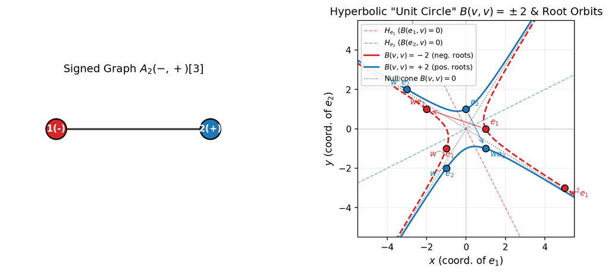

```
m=3, k=1: (s0*s1)^1 = [[-2, -1], [-1, -1]]
m=3, k=2: (s0*s1)^2 = [[5, 3], [3, 2]]
m=3, k=3: (s0*s1)^3 = [[-13, -8], [-8, -5]]
m=3, k=4: (s0*s1)^4 = [[34, 21], [21, 13]]
A2(+,-)[3 (Fibonacci)]: G_{2k+1} = [2, 5, 13, 34], lambda = 2.6180 (verified k=1..4)
A2(+,-)[4 (a=sqrt(2))]: G_{2k+1} = [3, 11, 41, 153], lambda = 3.7321 (verified k=1..4)
A2(+,-)[6 (a=sqrt(3))]: G_{2k+1} = [4, 19, 91, 436], lambda = 4.7913 (verified k=1..4)
A2(+,-)[oo (Pell)]: G_{2k+1} = [5, 29, 169, 985], lambda = 5.8284 (verified k=1..4)
```

#### Lean 4 Proof

In [`RankTwo.lean`](https://github.com/jkylearmstrong/mixed.sign.coxeter.systems/blob/main/lean/MixedSignCoxeter/RankTwo.lean), [`a2_pm_3_fibonacci_powers`](https://github.com/jkylearmstrong/mixed.sign.coxeter.systems/blob/main/lean/MixedSignCoxeter/RankTwo.lean#L187) proves the Fibonacci matrix formula by induction on $k$, using `Nat.fib_add_two` to match the matrix multiplication recurrence. [`rank2_pm_infinite_order`](https://github.com/jkylearmstrong/mixed.sign.coxeter.systems/blob/main/lean/MixedSignCoxeter/RankTwo.lean#L143) proves $(s_0 s_1)^k \neq I$ for all $c \neq 0$ and $k \ge 1$ by showing that the $(0,0)$ entry of $(-(s_0 s_1))^k$ strictly exceeds $1$:

```
theorem det_rank2_pm (c : ℝ) :
    Matrix.det !![(2 : ℝ), c; c, -2] = -(4 + c ^ 2)

theorem rank2_pm_infinite_order (c : ℝ) (hc : c ≠ 0) (k : ℕ) (hk : 1 ≤ k) :
    (s0PM c * s1PM c) ^ k ≠ 1

theorem a2_pm_3_fibonacci_powers (k : ℕ) (hk : 1 ≤ k) :
    (s0A2PM * s1A2PM) ^ k =
      ((-1 : ℝ) ^ k) •
        !![(Nat.fib (2 * k + 1) : ℝ), (Nat.fib (2 * k) : ℝ);
           (Nat.fib (2 * k) : ℝ),     (Nat.fib (2 * k - 1) : ℝ)]
```

### 3.3 Roots and Length in Classical Coxeter Systems: Proposition 3.10

*Results covered: Proposition 3.10 in full generality, $\Phi = \Phi^+ \sqcup -\Phi^+$, and the Exchange Property and faithful Coxeter presentation for every classical Coxeter graph.*

The dissertation quotes Proposition 3.10 from Björner–Brenti (Björner and Brenti 2005) without proof:

> **Proposition 3.10.** If $(W, S, B)$ is a classical Coxeter system, $w \in W$ and $s_i \in S$, then
> $$w(e_i) \in \Phi^+ \iff \ell(w s_i) > \ell(w).$$

We prove it in Lean for the matrix group $W(S) \subset GL_n(\mathbb{R})$ generated by the reflections $s_i$, with $\ell$ the word length in $W(S)$ itself, under the hypothesis [`IsCoxeterForm`](https://github.com/jkylearmstrong/mixed.sign.coxeter.systems/blob/main/lean/MixedSignCoxeter/RootPositivity.lean#L258): $B(e_i, e_i) = 2$ and, for $i \neq j$, either $B(e_i, e_j) = -2\cos(\pi/m)$ with an integer $m \ge 2$ or $B(e_i, e_j) \le -2$. This covers every classical Coxeter graph ($m(i,j) = \infty$ gives $-2$) and also arbitrary edge weights $\le -2$. The argument is that of Humphreys, carried out entirely inside the matrix group (Humphreys 1990, Thm. 5.4):

1. **Parity.** $\det s_i = -1$, so $\det w = (-1)^{\ell(w)}$ and $\ell(w s_i) = \ell(w) \pm 1$ ([`len_append_singleton`](https://github.com/jkylearmstrong/mixed.sign.coxeter.systems/blob/main/lean/MixedSignCoxeter/RootPositivity.lean#L143)).
2. **Chebyshev coefficients.** With $c = 2\cos\theta$ and $t_0 = 0$, $t_1 = 1$, $t_{k+2} = c\,t_{k+1} - t_k$, one has $t_k \sin\theta = \sin k\theta$ ([`chebSeq_mul_sin`](https://github.com/jkylearmstrong/mixed.sign.coxeter.systems/blob/main/lean/MixedSignCoxeter/RootPositivity.lean#L269)). For $\theta = \pi/m$ this gives $t_k \ge 0$ for $k \le m$, $t_{2m} = 0$ and $t_{2m+1} = 1$.
3. **Braid relation.** If $B(e_i, e_j) = -2\cos(\pi/m)$ then $(s_i s_j)^m = 1$ ([`wordProd_altList_two_mul`](https://github.com/jkylearmstrong/mixed.sign.coxeter.systems/blob/main/lean/MixedSignCoxeter/RootPositivity.lean#L380)): $(s_i s_j)^m$ fixes $e_i$, $e_j$ (step 2) and every vector $B$-orthogonal to both, and these span $\mathbb{R}^n$ because $4 - c^2 = 4\sin^2(\pi/m) > 0$.
4. **Rank two.** If $u$ is a word in $s_i, s_j$ with $\ell(u s_i) = |u| + 1$, then $u$ is the alternating word $\cdots s_i s_j$ of length $p < m$, so $u\,e_i = t_{p+1} e_i + t_p e_j$ (or with the coefficients swapped) has nonnegative coefficients ([`rank_two_coeffs`](https://github.com/jkylearmstrong/mixed.sign.coxeter.systems/blob/main/lean/MixedSignCoxeter/RootPositivity.lean#L535)).
5. **Induction on $\ell(w)$.** Let $s_j$ end a reduced word for $w$. Among factorizations $w = x\,u$ with $u$ a word in $s_i, s_j$ and $\ell(w) = \ell(x) + |u|$, pick one with $\ell(x)$ minimal. Minimality forces $\ell(x s_i) > \ell(x)$ and $\ell(x s_j) > \ell(x)$, so $x e_i, x e_j \ge 0$ by induction, and $w e_i = x(\alpha e_i + \beta e_j)$ with $\alpha, \beta \ge 0$ by step 4 ([`nonneg_of_len_lt`](https://github.com/jkylearmstrong/mixed.sign.coxeter.systems/blob/main/lean/MixedSignCoxeter/RootPositivity.lean#L574)). If instead $\ell(w s_i) < \ell(w)$, apply this to $w s_i$: $w e_i = -(w s_i) e_i \le 0$.

This gives [`prop_3_10`](https://github.com/jkylearmstrong/mixed.sign.coxeter.systems/blob/main/lean/MixedSignCoxeter/RootPositivity.lean#L680) (and [`prop_3_10_classical`](https://github.com/jkylearmstrong/mixed.sign.coxeter.systems/blob/main/lean/MixedSignCoxeter/RootPositivity.lean#L901) for a classical graph $\Gamma$), and with it [`root_pos_or_neg`](https://github.com/jkylearmstrong/mixed.sign.coxeter.systems/blob/main/lean/MixedSignCoxeter/RootPositivity.lean#L698): every root of a classical system is positive or negative. Proposition 3.12 shows this dichotomy fails for $A_2(-,+)$, which is the precise sense in which mixed-sign systems “behave in a different fashion”.

Two further consequences close the loop with Theorem 3.9. If $w = s_{a_1} \cdots s_{a_k}$ is reduced and $\ell(s\,w) < \ell(w)$, then $w^{-1} e_s < 0$, so some prefix $y = s_{a_t} \cdots s_{a_1}$ sends $e_s$ to a multiple of $e_{a_{t+1}}$; $B$-invariance then gives $y\, s\, y^{-1} = s_{a_{t+1}}$ ([`conj_of_root_eq`](https://github.com/jkylearmstrong/mixed.sign.coxeter.systems/blob/main/lean/MixedSignCoxeter/RootPositivity.lean#L743)) and hence $s\,w = s_{a_1} \cdots \widehat{s_{a_{t+1}}} \cdots s_{a_k}$. This is the Exchange Property, [`exchange_of_isCoxeterForm`](https://github.com/jkylearmstrong/mixed.sign.coxeter.systems/blob/main/lean/MixedSignCoxeter/RootPositivity.lean#L796). Feeding it into Theorem 3.9 shows that **the matrix group of every classical Coxeter graph is a Coxeter group**, that is, the geometric representation is faithful ([`isClassicalCoxeter_of_isCoxeterForm`](https://github.com/jkylearmstrong/mixed.sign.coxeter.systems/blob/main/lean/MixedSignCoxeter/RootPositivity.lean#L882), [`classical_graph_isClassicalCoxeter`](https://github.com/jkylearmstrong/mixed.sign.coxeter.systems/blob/main/lean/MixedSignCoxeter/RootPositivity.lean#L912)). Before this, Theorem 3.9 was proved as an equivalence but nothing showed that an all-positive graph satisfies its hypotheses.

#### Python Verification

`verify_prop_3_10` enumerates every element of length $< 4$ by breadth-first search on the Cayley graph (so lengths are exact) and tests both sides of Proposition 3.10 for every generator. Classical graphs of finite, affine and hyperbolic type have no failures; mixed-sign graphs fail on both counts.

```
B3 (finite)            pairs checked:  48  Prop 3.10 failures:   0  roots neither positive nor negative:   0
H3 (finite)            pairs checked:  48  Prop 3.10 failures:   0  roots neither positive nor negative:   0
~A2 (affine)           pairs checked:  57  Prop 3.10 failures:   0  roots neither positive nor negative:   0
[oo, 3] (hyperbolic)   pairs checked:  48  Prop 3.10 failures:   0  roots neither positive nor negative:   0
A2(-,+) (mixed)        pairs checked:  14  Prop 3.10 failures:   6  roots neither positive nor negative:   5
A3(+,-,+) (mixed)      pairs checked:  51  Prop 3.10 failures:  27  roots neither positive nor negative:  25
```

#### Lean 4 Proof

```
theorem prop_3_10 (hS : IsCoxeterForm S) (w : List (Fin n)) (i : Fin n) :
    IsPositive (S.wordProd w *ᵥ e i) ↔
      len S (S.wordProd w) < len S (S.wordProd w * reflectionMatrix S.B i)

theorem root_pos_or_neg (hS : IsCoxeterForm S) (w : List (Fin n)) (i : Fin n) :
    IsPositive (S.wordProd w *ᵥ e i) ∨ IsPositive (-(S.wordProd w *ᵥ e i))

theorem classical_graph_isClassicalCoxeter {Γ : MixedSignCoxeterGraph n} (hΓ : Γ.IsClassical) :
    SatisfiesExchangeProperty Γ.toReflectionSystem ∧
      SatisfiesDeletionProperty Γ.toReflectionSystem ∧
      ∃ (M : CoxeterMatrix (Fin n)) (φ : M.Group →* Matrix (Fin n) (Fin n) ℝ),
        Function.Injective φ ∧
          ∀ i, φ (M.toCoxeterSystem.simple i) = reflectionMatrix Γ.toReflectionSystem.B i
```

### 3.4 Odd Cycles, Deletion Failure, and Non-Classicality

*Results covered: Lemma 3.21, Theorem 1.2, Corollary 1.3, Theorem 1.6.*

Odd cycles expose two sharp separations between mixed-sign and classical Coxeter systems:

1. **Failure of the Deletion Property (Lemma 3.21, Theorem 1.2, Corollary 1.3)**: In $W(\widetilde{A_{-2}})$, all three nodes are negative and all edges have weight $3$. The group is finite of order $24$ ($\cong S_4 \cong W(A_3)$, [`remark_3_23_tildeAminus2_iso_S4`](https://github.com/jkylearmstrong/mixed.sign.coxeter.systems/blob/main/lean/MixedSignCoxeter/RemarksAndClassical.lean#L186), [`remark_3_23_card`](https://github.com/jkylearmstrong/mixed.sign.coxeter.systems/blob/main/lean/MixedSignCoxeter/RemarksAndClassical.lean#L199), Remark 3.23) with $(s_1 s_2 s_3)^4 = 1$, yet the Deletion Property fails: $w = s_1 s_2 s_1 s_3 s_1$ (length $5$) equals $s_3 s_1 s_2$ (length $3$), so $w$ is not reduced, but no 2-letter deletion from $w$ equals $w$. By parabolic transfer ([`not_deletion_of_contains_tildeAminus2`](https://github.com/jkylearmstrong/mixed.sign.coxeter.systems/blob/main/lean/MixedSignCoxeter/ParabolicTransfer.lean#L195)), **any** reflection system containing an induced copy of $\widetilde{A_{-2}}$ fails the Deletion Property—covering both the dissertation’s tail family $\Gamma_{3+k}$ ([`theorem_1_2_tail_family`](https://github.com/jkylearmstrong/mixed.sign.coxeter.systems/blob/main/lean/MixedSignCoxeter/ParabolicTransfer.lean#L253)) and orthogonal extensions `tildeAminus2Extended k` ([`theorem_1_2_extended_family`](https://github.com/jkylearmstrong/mixed.sign.coxeter.systems/blob/main/lean/MixedSignCoxeter/ParabolicTransfer.lean#L267), Theorem 1.2). Because the Deletion Property is invariant under $\mathcal{O}$-conjugacy ([`deletion_invariant_of_O_conjugate`](https://github.com/jkylearmstrong/mixed.sign.coxeter.systems/blob/main/lean/MixedSignCoxeter/ClassicalDeletion.lean#L137)), none of these systems is $\mathcal{O}$-conjugate to any system satisfying the Deletion Property ([`corollary_1_3_not_conjugate_to_deletion`](https://github.com/jkylearmstrong/mixed.sign.coxeter.systems/blob/main/lean/MixedSignCoxeter/ClassicalDeletion.lean#L183), Corollary 1.3).
2. **Signature Obstruction on Odd Cycles (Lemma 3.25 & Theorem 1.6)**: Whereas $W(\widetilde{A_2})$ is infinite ([`tildeA2_infinite_order`](https://github.com/jkylearmstrong/mixed.sign.coxeter.systems/blob/main/lean/MixedSignCoxeter/CyclesAndDeletion.lean#L597), Lemma 3.25), for any odd cycle $\widetilde{A_{-n}}$ ($m = n+1$ odd, $n$ even), $v^T B v = -\sum_i (v_i + v_{i+1})^2 < 0$ for all $v \neq 0$ ([`oddCycleNegForm_negDef`](https://github.com/jkylearmstrong/mixed.sign.coxeter.systems/blob/main/lean/MixedSignCoxeter/CyclesAndDeletion.lean#L437), strictly negative definite, with $\det(-B(\widetilde{A_{-n}})) = 4$ proved in [`remark_3_26_det_neg_odd_cycle`](https://github.com/jkylearmstrong/mixed.sign.coxeter.systems/blob/main/lean/MixedSignCoxeter/RemarksAndClassical.lean#L424) and $|W(\widetilde{A_{-4}})| = 1920 = |W(D_5)|$, $|W(\widetilde{A_{-6}})| = 322560 = |W(D_7)|$, Remark 3.26). Meanwhile $\widetilde{A_n}$ is positive semidefinite and degenerate on $(1,\dots,1)^T$ ([`cyclePosForm_posSemidef`](https://github.com/jkylearmstrong/mixed.sign.coxeter.systems/blob/main/lean/MixedSignCoxeter/CyclesAndDeletion.lean#L381), [`cyclePosForm_degenerate`](https://github.com/jkylearmstrong/mixed.sign.coxeter.systems/blob/main/lean/MixedSignCoxeter/CyclesAndDeletion.lean#L386)), so the two systems cannot be $\mathcal{O}$-conjugate ([`oddCycle_not_O_conjugate`](https://github.com/jkylearmstrong/mixed.sign.coxeter.systems/blob/main/lean/MixedSignCoxeter/CyclesAndDeletion.lean#L479), Theorem 1.6).

#### Python Verification

Below we draw $\widetilde{A_{-2}}$, enumerate all $24$ elements of $W(\widetilde{A_{-2}})$, verify $s_1 s_2 s_1 s_3 s_1 = s_3 s_1 s_2$, and exhaustively check that all $\binom{5}{2} = 10$ two-letter deletions of `[0, 1, 0, 2, 0]` fail to reproduce $w$:

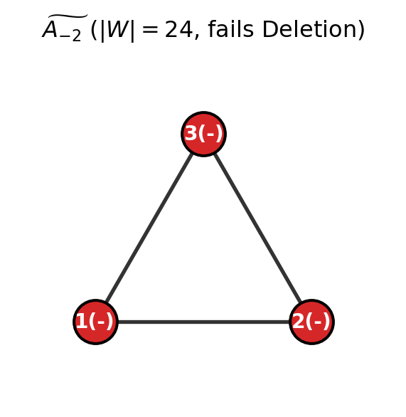

```
Complete enumeration: True | Group order: 24
s1 s2 s1 s3 s1 == s3 s1 s2: True
2-letter deletions of [0,1,0,2,0] yielding same element: []
```

#### Lean 4 Proof

In [`CyclesAndDeletion.lean`](https://github.com/jkylearmstrong/mixed.sign.coxeter.systems/blob/main/lean/MixedSignCoxeter/CyclesAndDeletion.lean) and [`ClassicalDeletion.lean`](https://github.com/jkylearmstrong/mixed.sign.coxeter.systems/blob/main/lean/MixedSignCoxeter/ClassicalDeletion.lean), because all entries of the reflections of $\widetilde{A_{-2}}$ are integers in $\{0, \pm 1\}$, we define integer reflection matrices `sTildeAminus2Z` and lift them to $\mathbb{R}$ via `Int.cast`, allowing Lean’s `decide` tactic to exhaustively check all $10$ two-letter deletions in [`tildeAminus2_fails_deletion`](https://github.com/jkylearmstrong/mixed.sign.coxeter.systems/blob/main/lean/MixedSignCoxeter/CyclesAndDeletion.lean#L120). Embedding $\mathbb{R}^3$ into $\mathbb{R}^{3+k}$ ([`theorem_1_2_infinite_family`](https://github.com/jkylearmstrong/mixed.sign.coxeter.systems/blob/main/lean/MixedSignCoxeter/CyclesAndDeletion.lean#L279)) then combines with [`deletion_invariant_of_O_conjugate`](https://github.com/jkylearmstrong/mixed.sign.coxeter.systems/blob/main/lean/MixedSignCoxeter/ClassicalDeletion.lean#L137) to prove [`corollary_1_3_not_conjugate_to_deletion`](https://github.com/jkylearmstrong/mixed.sign.coxeter.systems/blob/main/lean/MixedSignCoxeter/ClassicalDeletion.lean#L183):

```
theorem tildeAminus2_fails_deletion :
    let S := tildeAminus2Graph.toReflectionSystem
    let w : List (Fin 3) := [0, 1, 0, 2, 0]
    S.wordProd w = S.wordProd [2, 0, 1] ∧
    ∀ i j : Fin 5, i < j → S.wordProd (deleteTwo w i.val j.val) ≠ S.wordProd w

theorem corollary_1_3_not_conjugate_to_deletion (k : ℕ)
    (S₁ : ReflectionSystem (3 + k)) (hdel : SatisfiesDeletionProperty S₁) :
    ¬ ∃ P : SignedPerm (3 + k),
      (tildeAminus2Extended k).toBilinearForm =
        P.toMatrixᵀ * S₁.B * P.toMatrix

theorem oddCycleNegForm_negDef (m : ℕ) [NeZero m] (hm : Odd m) (v : Fin m → ℝ)
    (hv : v ≠ 0) :
    (∑ i : Fin m, ∑ j : Fin m, v i * cycleNegForm m i j * v j) < 0

theorem oddCycle_not_O_conjugate (m : ℕ) [NeZero m] (hm : Odd m) :
    (¬ ∃ P : ReflectionSystem.SignedPerm m,
      P.toMatrixᵀ * cyclePosForm m * P.toMatrix = cycleNegForm m) ∧
    (¬ ∃ P : ReflectionSystem.SignedPerm m,
      P.toMatrixᵀ * cyclePosForm m * P.toMatrix = -cycleNegForm m)
```

### 3.5 Spectral Radius Theory and Counterexamples

*Results covered: Theorems 3.27–3.28, Examples 3.29 & 3.33, Theorem 1.7.*

In classical Coxeter theory, a bipartite Coxeter element $w = s_+ s_-$ has eigenvalues $\lambda$ determined by the graph adjacency singular values $\mu$ via $\lambda^2 - (\mu^2 - 2)\lambda + 1 = 0$ ([`theorem_3_27_bipartite_coxeter_eigenvalue`](https://github.com/jkylearmstrong/mixed.sign.coxeter.systems/blob/main/lean/MixedSignCoxeter/SpectralRadius.lean#L226), [`eigen_analysis`](https://github.com/jkylearmstrong/mixed.sign.coxeter.systems/blob/main/lean/MixedSignCoxeter/SpectralClassification.lean#L344)). This yields A’Campo’s full spectral classification ([`theorem_3_27_classification`](https://github.com/jkylearmstrong/mixed.sign.coxeter.systems/blob/main/lean/MixedSignCoxeter/SpectralClassification.lean#L572), Theorem 3.27)—the form is spherical iff all eigenvalues satisfy $|\lambda| = 1$ and $1$ is not an eigenvalue, affine iff $|\lambda| = 1$ with eigenvalue $1$, and hyperbolic/indefinite iff $w$ has a real eigenvalue $\lambda > 1$—together with eigenvalue interlacing on induced subgraphs / node deletion ([`theorem_3_28_interlacing`](https://github.com/jkylearmstrong/mixed.sign.coxeter.systems/blob/main/lean/MixedSignCoxeter/SpectralClassification.lean#L781), [`theorem_3_28_strict`](https://github.com/jkylearmstrong/mixed.sign.coxeter.systems/blob/main/lean/MixedSignCoxeter/SpectralClassification.lean#L882), [`theorem_3_28_spectral_radius_strict_mono`](https://github.com/jkylearmstrong/mixed.sign.coxeter.systems/blob/main/lean/MixedSignCoxeter/SpectralRadius.lean#L269), Theorem 3.28), so bipartite Coxeter elements minimize the spectral radius. Both phenomena break down in the mixed-sign setting:

1. **Example 3.29 (Hyperbolic system with $\rho(w) = 1$)**: $A_3(+, +, -)$ is hyperbolic ($\det B = -8 < 0$, signature $(2, 1, 0)$), yet its principal polynomial is $(x + 1)^3$, so its spectral radius is $\rho(w) = 1$ and $(w + I)^3 = 0$ ([`w_A3_ppm_add_one_cube`](https://github.com/jkylearmstrong/mixed.sign.coxeter.systems/blob/main/lean/MixedSignCoxeter/SpectralRadius.lean#L72)).
2. **Theorem 1.7 / Theorem 3.34 / Example 3.33 (Bipartite element is not minimal)**: In the 6-node bipartite graph `example_3_33`, the **bipartite** principal element $w_{\mathrm{bp}} = s_1 s_4 s_6 s_2 s_3 s_5$ has spectral radius $\rho(w_{\mathrm{bp}}) \approx 5.55193$, strictly *larger* than the linear principal element $w_{\mathrm{lin}} = s_1 s_2 s_3 s_4 s_5 s_6$ ($\rho(w_{\mathrm{lin}}) \approx 3.05128$). (Similarly, Remark 3.30 shows that minimal spectral radii $\Lambda$ oscillate non-monotonically along $A_2(+,-) \subset A_3(-,+,+) \subset A_4(-,+,+,+) \subset A_5(-,+,+,+,+)$, verified in Lean via [`wA2Z_annihilated`](https://github.com/jkylearmstrong/mixed.sign.coxeter.systems/blob/main/lean/MixedSignCoxeter/RemarksAndClassical.lean#L481)–[`wA5Z_annihilated`](https://github.com/jkylearmstrong/mixed.sign.coxeter.systems/blob/main/lean/MixedSignCoxeter/RemarksAndClassical.lean#L484) and [`remark_3_30_A2_root_gt`](https://github.com/jkylearmstrong/mixed.sign.coxeter.systems/blob/main/lean/MixedSignCoxeter/RemarksAndClassical.lean#L488), [`remark_3_30_A4_root_gt`](https://github.com/jkylearmstrong/mixed.sign.coxeter.systems/blob/main/lean/MixedSignCoxeter/RemarksAndClassical.lean#L500), [`remark_3_30_A5_roots_lt`](https://github.com/jkylearmstrong/mixed.sign.coxeter.systems/blob/main/lean/MixedSignCoxeter/RemarksAndClassical.lean#L513).)

#### Python Verification

Below we plot the signed diagrams of $A_3(+, +, -)$ (Example 3.29) and the 6-node bipartite graph of Example 3.33 alongside the complex-plane eigenvalues of $w_{\mathrm{lin}}$ and $w_{\mathrm{bp}}$ relative to the unit circle, confirming $\rho(w_{\mathrm{bp}}) > 4 > \rho(w_{\mathrm{lin}})$:

```
Example 3.29 factored charpoly: (x + 1)**3 | rho = 1.0
Example 3.33 p_lin(x) = x**6 + 8*x**5 + 24*x**4 + 33*x**3 + 24*x**2 + 8*x + 1 | rho = 3.05129
Example 3.33 p_bp(x)  = x**6 + 9*x**5 + 24*x**4 + 31*x**3 + 24*x**2 + 9*x + 1 | rho = 5.55193
```

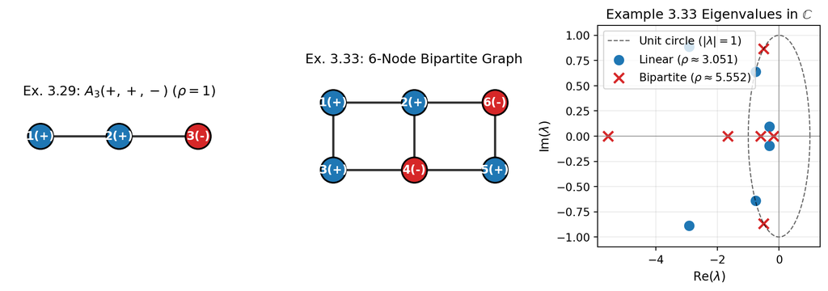

Signed Coxeter graphs for Example 3.29 and Example 3.33 (left, center) and complex-plane eigenvalues of Example 3.33 (right). Blue circles show eigenvalues of the linear element $w_{\mathrm{lin}}$ ($\rho \approx 3.051$), red crosses show eigenvalues of the bipartite element $w_{\mathrm{bp}}$ ($\rho \approx 5.552$), and the dashed circle marks the unit circle $|\lambda| = 1$.

#### Lean 4 Proof

For Example 3.29, [`w_A3_ppm_add_one_cube`](https://github.com/jkylearmstrong/mixed.sign.coxeter.systems/blob/main/lean/MixedSignCoxeter/SpectralRadius.lean#L72) verifies $(w + I)^3 = 0$, which forces every eigenvalue $\lambda$ to equal $-1$ ([`w_A3_ppm_eigenvalue_eq_neg_one`](https://github.com/jkylearmstrong/mixed.sign.coxeter.systems/blob/main/lean/MixedSignCoxeter/SpectralRadius.lean#L85)). For Example 3.33, we verify the degree-6 annihilating polynomials over $\mathbb{Z}$ via `decide` ([`wLinEx333Z_annihilated`](https://github.com/jkylearmstrong/mixed.sign.coxeter.systems/blob/main/lean/MixedSignCoxeter/SpectralRadius.lean#L196), [`wBpEx333Z_annihilated`](https://github.com/jkylearmstrong/mixed.sign.coxeter.systems/blob/main/lean/MixedSignCoxeter/SpectralRadius.lean#L202)), prove algebraically that $p_{\mathrm{lin}}(\lambda) \neq 0$ whenever $|\lambda| \ge 4$ ([`pLinEx333_no_root_ge_four`](https://github.com/jkylearmstrong/mixed.sign.coxeter.systems/blob/main/lean/MixedSignCoxeter/SpectralRadius.lean#L133)), and apply the Intermediate Value Theorem on $[-6, -4]$ to show $p_{\mathrm{bp}}$ has a root $\lambda \in [-6, -4]$ ([`pBpEx333_has_root_gt_four`](https://github.com/jkylearmstrong/mixed.sign.coxeter.systems/blob/main/lean/MixedSignCoxeter/SpectralRadius.lean#L120), [`theorem_3_34_bipartite_exceeds_linear`](https://github.com/jkylearmstrong/mixed.sign.coxeter.systems/blob/main/lean/MixedSignCoxeter/SpectralRadius.lean#L211)):

```
theorem w_A3_ppm_eigenvalue_eq_neg_one (lam : ℝ) (v : Fin 3 → ℝ) (hv : v ≠ 0)
    (heig : w_A3_ppm.mulVec v = lam • v) : lam = -1

theorem pLinEx333_no_root_ge_four (lam : ℝ) (hlam : 4 ≤ |lam|) :
    pLinEx333 lam ≠ 0

theorem pBpEx333_has_root_gt_four :
    ∃ lam : ℝ, lam ∈ Set.Icc (-6 : ℝ) (-4) ∧ pBpEx333 lam = 0
```

## 4 Computational Verifications Beyond the Dissertation

*Results covered: Theorem 1.6 remark, Appendix D, Remark A.3, Question 3.35. Full details in `verifications.md`; tests in [`tests/test_verifications.py`](https://github.com/jkylearmstrong/mixed.sign.coxeter.systems/blob/main/tests/test_verifications.py).*

1. **$W(\widetilde{A_{-n}}) \cong W(D_{n+1})$ for every even $n$** ([`isomorphisms.py`](https://github.com/jkylearmstrong/mixed.sign.coxeter.systems/blob/main/src/mixed_sign_coxeter/isomorphisms.py)). The integer matrix $T$ whose columns are the $D_{n+1}$ roots $r_i = (-1)^i(\varepsilon_{i+1} - \varepsilon_{i+2})$ ($0 \le i < n$) and $r_n = \varepsilon_1 + \varepsilon_{n+1}$ satisfies $T^T T = -B(\widetilde{A_{-n}})$, so $w \mapsto T w T^{-1}$ sends each $s_i$ to the reflection in $r_i$. The orbit of the $r_i$ is the whole $D_{n+1}$ root system, so the image is exactly $W(D_{n+1})$. For odd $n$ the cycle is bipartite and the group is infinite (Theorem 1.4). This proves the conjecture stated after Theorem 1.6.
2. **Appendix D in Python.** The thesis’s GAP matrices equal the package generators of $W(\widetilde{A_{-4}})$, all 16 GAP relators hold, and Todd–Coxeter enumeration gives $[G : \langle f_1,\dots,f_4\rangle] = 16$, so the presentation has order $16 \cdot 120 = 1920$ and is faithful.
3. **Remark A.3: Table A.2 is not complete.** If $\Gamma$ is connected and $W(\Gamma)$ is finite then $B(\Gamma)$ is definite, which recovers Corollary 3.18 (graphs with both signs are infinite) and also excludes all-negative graphs with $-B$ not positive definite. An exhaustive search of rank 3 and 4 ([`finite_search.py`](https://github.com/jkylearmstrong/mixed.sign.coxeter.systems/blob/main/src/mixed_sign_coxeter/finite_search.py)) finds 4 finite rank-3 and 24 finite rank-4 graphs beyond Table A.2 and Figure A.1, all negative and non-bipartite (for example the negative $K_4$, of type $A_4$). Simply-laced searches at ranks 5 and 6 find 12 and 45 more.
4. **Question 3.35** ([`principal_search.py`](https://github.com/jkylearmstrong/mixed.sign.coxeter.systems/blob/main/src/mixed_sign_coxeter/principal_search.py)). Over all 4,026 simply-laced graphs with a cycle on 4–6 nodes, the bipartite element fails to minimize in 96 graphs, always with mixed signs, and is the *maximum* in 72 of them. The smallest example is the alternating 4-cycle $(+,-,+,-)$: bipartite radius $3 + 2\sqrt{2} \approx 5.828$, circuit radius $\approx 3.546$. Orienting all mixed edges the same way also fails to minimize in 564 of 3,183 mixed graphs. In Example 3.33, the first row of Table 3.1 ($\rho \approx 3.051$) is the global minimum and the (positive)(negative) row ($\rho \approx 7.148$) the global maximum.

## 5 Summary of Lean 4 Modules

Mixed-Sign Coxeter Statements

[output not shown]

[output cut: 77 more lines]

## 6 Formalization Scope, Python Coverage, and Dissertation Omissions

To maintain a transparent audit trail between the dissertation (Armstrong 2012), the Python package, and the Lean 4 formalization:

Formalization scope, Python verification coverage, and dissertation omissions.

| **Layer / Status** | **Covered Results & Scope** |
| --- | --- |
| **Formalized in Lean 4** (`lean/MixedSignCoxeter/`, `sorry`-free in `v4.35.0`) | **Ch. 1–2:** Theorems 1.1, 1.4 & 2.58; Corollaries 1.5, 2.38 & 2.46; Propositions 2.17, 2.21, 2.22, 2.28, 2.41 & 2.45; Lemmas 2.31, 2.32, 2.37 & 2.63; Definitions 2.47–2.51; Examples 2.36 & 2.52; mixe… |
| **Verified in Python** (`src/mixed_sign_coxeter/`, `tests/test_dissertation.py`, `tests/test_verifications.py`) | Exact symbolic/numerical checks for Howlett’s formula, principal polynomials, signatures, Mahler measures (`mahler_measure`), Appendix A finite catalogs (`table_a1`, `table_a2`, and the 4 rank-3 + 24 … |
| **Out of Scope for Lean 4** | Exhaustive graph-enumeration searches (Appendix A rank-3/rank-4 catalog completeness beyond `finite_connected_isDefinite`; Appendix B $A_n$ sign tables; Open Questions 2.59 & 3.35 exhaustive $k \le 8$… |

## 7 Lean 4 Formalization Architecture

Several design choices keep the Lean 4 (`v4.35.0`) formalization modular, `sorry`-free, and fast to verify (`lake build`):

- **Coordinate-free matrix representation (`ReflectionSystem.lean`)**: Rather than fixing a basis-free inner product space early, `ReflectionSystem n` packages a symmetric matrix $B \in \mathbb{R}^{n \times n}$ with $B_{ii} \neq 0$, allowing direct `ext`/`fin_cases`/`ring` proofs for reflections $s_i = I - \frac{2}{B_{ii}} e_i e_i^T B$, form preservation, and $\mathcal{O}$-conjugacy (`Conjugacy.lean`).
- **Inductive Howlett verification (`Howlett.lean`)**: [`howlett_U_mul_principalElement`](https://github.com/jkylearmstrong/mixed.sign.coxeter.systems/blob/main/lean/MixedSignCoxeter/Howlett.lean#L174) establishes $U(s_0 \cdots s_{n-1}) = -U^T$ by induction over prefix products `prefixProd S k` for arbitrary dimension $n$, avoiding case-by-case matrix inversion.
- **Exact integer reflection lifting (`CyclesAndDeletion.lean`, `SpectralRadius.lean`)**: For systems whose edge weights are $2$ or $3$ (entries in $\{0, -1, \pm 2\}$), reflections are defined over $\mathbb{Z}$ and mapped to $\mathbb{R}$ via `Int.cast`. This lets Lean’s `decide` tactic exhaustively verify the 10 two-letter deletions in $\widetilde{A_{-2}}$ ([`tildeAminus2_fails_deletion`](https://github.com/jkylearmstrong/mixed.sign.coxeter.systems/blob/main/lean/MixedSignCoxeter/CyclesAndDeletion.lean#L120)) and the degree-6 annihilating polynomials in Example 3.33 ([`wLinEx333Z_annihilated`](https://github.com/jkylearmstrong/mixed.sign.coxeter.systems/blob/main/lean/MixedSignCoxeter/SpectralRadius.lean#L196), [`wBpEx333Z_annihilated`](https://github.com/jkylearmstrong/mixed.sign.coxeter.systems/blob/main/lean/MixedSignCoxeter/SpectralRadius.lean#L202)).
- **Algebraic spectral-radius separation (`SpectralRadius.lean`)**: Instead of floating-point root approximation, Theorem 1.7 is proved rigorously by combining polynomial factorization bounds ([`pLinEx333_no_root_ge_four`](https://github.com/jkylearmstrong/mixed.sign.coxeter.systems/blob/main/lean/MixedSignCoxeter/SpectralRadius.lean#L133), $|\lambda_{\mathrm{lin}}| < 4$) with the Intermediate Value Theorem on $[-6, -4]$ ([`pBpEx333_has_root_gt_four`](https://github.com/jkylearmstrong/mixed.sign.coxeter.systems/blob/main/lean/MixedSignCoxeter/SpectralRadius.lean#L120), $|\lambda_{\mathrm{bp}}| \ge 4$).

## 8 References

Armstrong, Johnathon Kyle. 2012. “Principal Elements of Mixed-Sign Coxeter Systems.” PhD thesis, Florida State University. https://repository.lib.fsu.edu/islandora/object/fsu:182755/datastream/PDF/view.

Björner, Anders, and Francesco Brenti. 2005. *Combinatorics of Coxeter Groups*. Vol. 231. Graduate Texts in Mathematics. Springer.

Howlett, Robert B. 1982. “Coxeter Groups and $M$-Matrices.” *Bulletin of the London Mathematical Society* 14 (2): 137–41.

Humphreys, James E. 1990. *Reflection Groups and Coxeter Groups*. Vol. 29. Cambridge Studies in Advanced Mathematics. Cambridge University Press.

Moura, Leonardo de, and Sebastian Ullrich. 2021. “The Lean 4 Theorem Prover and Programming Language.” *Automated Deduction – CADE 28*, Lecture notes in computer science, vol. 12699: 625–35.

The mathlib Community. 2020. “The Lean Mathematical Library.” *Proceedings of the 9th ACM SIGPLAN International Conference on Certified Programs and Proofs (CPP 2020)*, 367–81.